# Predicting the FIFA World Cup’s Winner Using Machine Learning

## 3.4 Video game Scores

The following figure compares the difference between teams using the overall video game index and the FIFA ranking Index for the years when World Cups were played in the sample. We can observe that both index capture a similar pattern comparing the relative strength of two teams. However, as both represent different ways to measure the skills of teams, they are not the same. More recent video games show an overall increase in the quality of the teams as well as less variation within teams as historically weaker nations have improved their quality.

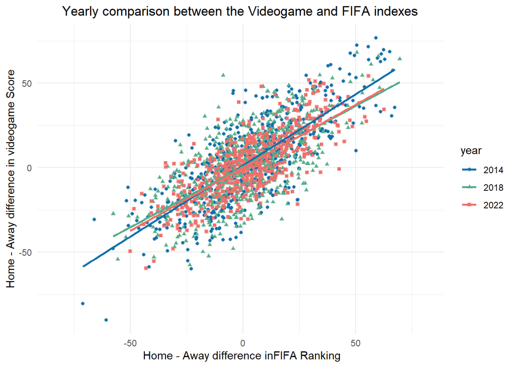

```r
# Relation game score and FIFA ranking
#----------------------------------------------------------------------

# Yearly graph relating FIFA ranking and videogame scores
results %>%
  filter(year== 2014 | year==2018 | year ==2022) %>%
  mutate(year=factor(year)) %>%
  ggplot(aes(y=overall_dha , x=ranking_fifa_dha, color=year , shape = year)) +
  geom_point(alpha=0.5, aes(color=year)) +
  scale_color_manual(values = colors_3) +
  geom_point(size = 1) +
  geom_smooth(method = "lm", se = F) +
  labs(y="Home - Away difference in videogame Score", x= " Home - Away difference inFIFA Ranking",
       title="Yearly comparison between the Videogame and FIFA indexes") +
  theme_minimal() + theme(plot.title = element_text(hjust = 0.5))
```

## 3.5 Historical results:

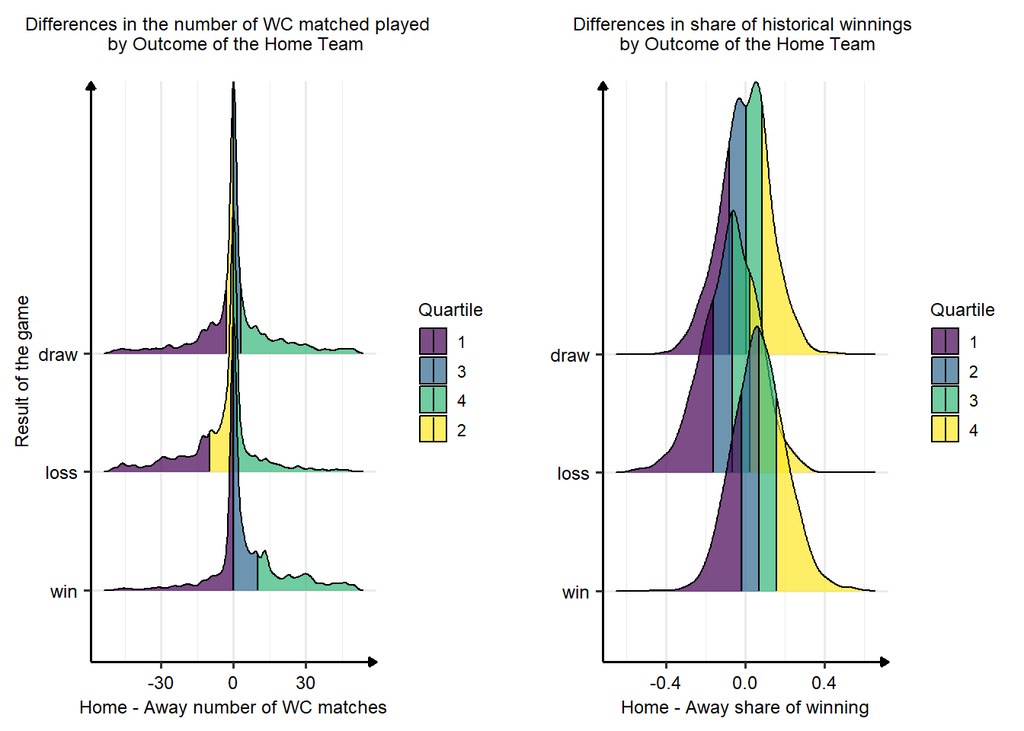

```r
# Share of winnings
w1<- results %>%
  filter(n_matches_wch_dha < 51 & n_matches_wch_dha > -51) %>%
  ggplot(aes(x = n_matches_wch_dha, y = reorder(home_result, desc(home_result)), fill = factor(..quantile..))) +
    stat_density_ridges(quantiles = c(0.25 , 0.50, 0.75)
                        , quantile_lines = TRUE
                        , geom = "density_ridges_gradient"
                        , alpha = 0.6
                        , scale = 2.3) +
  scale_fill_viridis(discrete = TRUE
                       , name = "Quartile"
                       , alpha = 0.7
                       , option = "viridis") + theme_per() +
   labs(title="Differences in the number of WC matched played  \n by Outcome of the Home Team", x="Home - Away number of WC matches" , y="Result of the game", fill= "Type")

w2<- ggplot(results, aes(x = sh_win_hist_dha, y = reorder(home_result, desc(home_result)), fill = factor(..quantile..))) +
    stat_density_ridges(quantiles = c(0.25 , 0.5 , 0.75)
                        , quantile_lines = TRUE
                        , geom = "density_ridges_gradient"
                        , alpha = 0.6
                        , scale = 2.3) +
  scale_fill_viridis(discrete = TRUE
                       , name = "Quartile"
                       , alpha = 0.7
                       , option = "viridis" ) + theme_per() +
   labs(title="Differences in share of historical winnings \n by Outcome of the Home Team", x="Home - Away share of winning" , y="", fill= "Type")

# Include both graphs
grid.arrange(w1, w2, ncol = 2)
```

## 3.6 Historical results since 1994

If we take the results since the FIFA ranking was created, we can compare the distribution of results to the strength of the opponents that each team faced. As we saw previously, the distribution of differences in the share of won matches has around 75% of the values on the positive side, whereas the distribution of losses is more on the negative side. The average strength of the opponents faced by the teams follows a close pattern. The majority of teams that won have faced historically stronger rivals than their opponents.

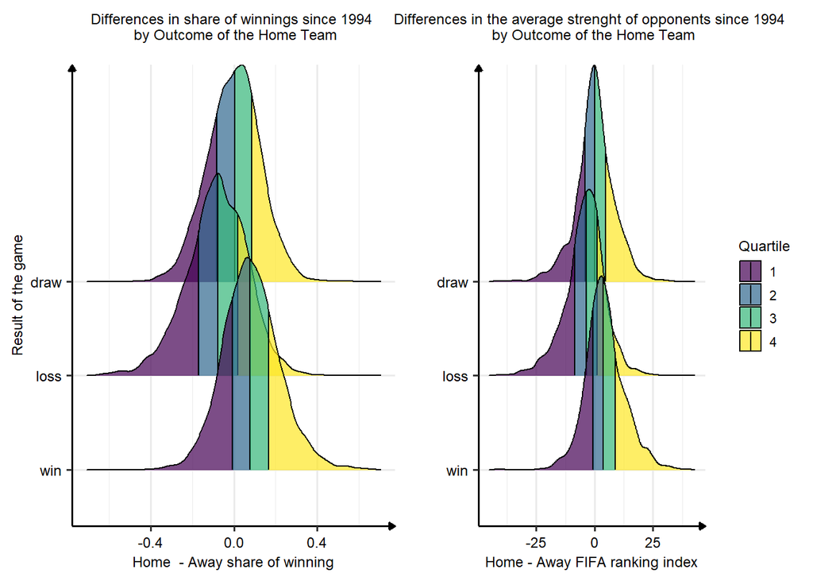

```r
p1<- results %>%
  mutate(outcome = sh_win_dha) %>%
  ggplot(aes(x = outcome, y = reorder(home_result, desc(home_result)), fill = factor(..quantile..))) +
    stat_density_ridges(quantiles = c(0.25 , 0.5 , 0.75)
                        , quantile_lines = TRUE
                        , geom = "density_ridges_gradient"
                        , alpha = 0.6
                        , scale = 2.3) +
  scale_fill_viridis(discrete = TRUE
                       , name = "Quartile"
                       , alpha = 0.7
                       , option = "viridis") + theme_per() +
   labs(title="Differences in share of winnings since 1994 \n by Outcome of the Home Team", x="Home  - Away share of winning" , y="Result of the game", fill= "Type") + theme(legend.position="none")

p2 <- results %>%
  mutate(outcome = av_rf_opp_dha) %>%
  ggplot(aes(x = outcome, y = reorder(home_result, desc(home_result)), fill = factor(..quantile..))) +
    stat_density_ridges(quantiles = c(0.25 , 0.5 , 0.75)
                        , quantile_lines = TRUE
                        , geom = "density_ridges_gradient"
                        , alpha = 0.6
                        , scale = 2.3) +
  scale_fill_viridis(discrete = TRUE
                       , name = "Quartile"
                       , alpha = 0.7
                       , option = "viridis") + theme_per() +
   labs(title="Differences in the average strenght of opponents since 1994 \n by Outcome of the Home Team", x="Home - Away FIFA ranking index", y="" ,fill= "Type")

grid.arrange(p1, p2, ncol = 2)
```